# RRRR 8. Statistical Modeling and Knitr

Jeong Lim

August 31, 2016

## Introduction

Focus on how to make your analysis really reproducible

- Incorporating analyses into the Markup : `chunk` options
- Computationally intensive code: chunk option `cache`
- Including non-R code in code chunks (ex. SAS code)

## Code Chunks

````
```{r}

```
````

Code chunk with option

````
```{r NAME, OPTIONS HERE}

```
````

Global option

````
```{r,  include=FALSE }
knitr::opts_chunk$set(OPTIONS HERE)
```
````

## [Chunk options](http://www.rstudio.com/wp-content/uploads/2015/03/rmarkdown-reference.pdf)

```
echo=FALSE        Don't include the code
results="hide"    Don't include the output
include=FALSE     Don't show code or output
eval=FALSE        Don't evaluate the code at all

collapse=TRUE     Collapse all the source and ouput blocks into a single block
warning=FALSE     Don't show R warnings
message=FALSE     Don't show R messages
error=FALSE       Don't show R error
cache=TRUE        Cache code chunk
tidy=TRUE         Reformat code in a tidy way
comment=NA        Remove ##
```

## Chunk options example

- numeric vector to select source code ; e.g) `echo=1`, `echo=c(1,3)`, `echo=-(1:2)`

code chunk without option

````
```{r withoutoption}
cars[1:4,]
sum(cars$speed)
sum(cars$dist)
mean(cars)
plot(cars$speed, cars$dist)
```
````

It looks like

```r
cars[1:4,]
```

```
##   speed dist
## 1     4    2
## 2     4   10
## 3     7    4
## 4     7   22
```

```r
sum(cars$speed)
```

```
## [1] 770
```

```r
sum(cars$dist)
```

```
## [1] 2149
```

```r
mean(cars)
```

```
## [1] NA
```

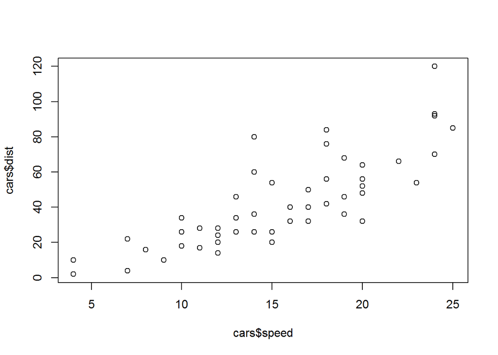

```r
plot(cars$speed, cars$dist)
```

code chunk with options

````
```{r withoption, echo=2:3,  warning=FALSE, collapse=TRUE, comment=NA, fig.align='center', fig.width=4}
cars[1:4,]
sum(cars$speed)
sum(cars$dist)
mean(cars)
plot(cars$speed, cars$dist)
```
````

It looks like

```
  speed dist
1     4    2
2     4   10
3     7    4
4     7   22
  sum(cars$speed)
[1] 770
sum(cars$dist)
[1] 2149
[1] NA
```

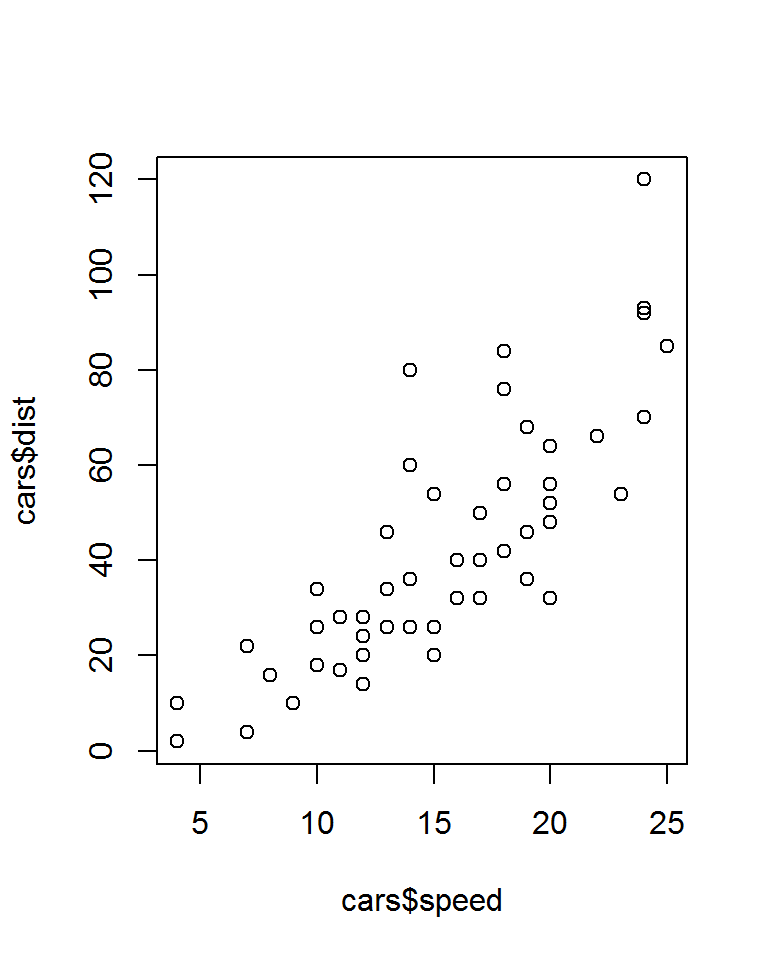

## [Chunk options example:`tidy`](http://yihui.name/formatR/)

- `tidy_source()` function in the formatR package make code tidy to improve readability
  - long lines of code and comments are reorganized into appropriately shorter ones
  - spaces and indent are added where necessary
  - comments are preserved in most cases
  - the number of spaces to indent the code (i.e. tab width) can be specified (default is 4)
  - an else statement in a separate line without the leading } will be moved one line back
  - = as an assignment operator can be replaced with <-
  - the left brace { can be moved to a new line

```r
library(formatR)
source("C:/Users/limje/Desktop/Reproducible/Jeong/UglyScript.R")
tidy_source("UglyScript.R", file="BeautifulScript.R")
```

## Showing code & result inline

- Inline static code : single backticks

ex) This is example R code : `MeanRiver <- mean(rivers)`

- Inline dynamic code : r after the first single backtick

ex) The mean length of 141 major rivers in North America is 591

## Dynamically including Modular Analysis files

- Long R source code chunks
- Same code in muliple documents (eg.article and slide show presentation)
- Interested in specific parts of analysis

Source from a local file

```r
source("C:/Users/limje/Desktop/Reproducible/Jeong/MainAnalysis.R")
```

Source from a secure URL

```r
library(devtools)
source_url("http://bit.ly/1D5p1w6")
```

```
## SHA-1 hash of file is ff75a88b90decfcaefc9903bbc283e1fc4cd2339
```

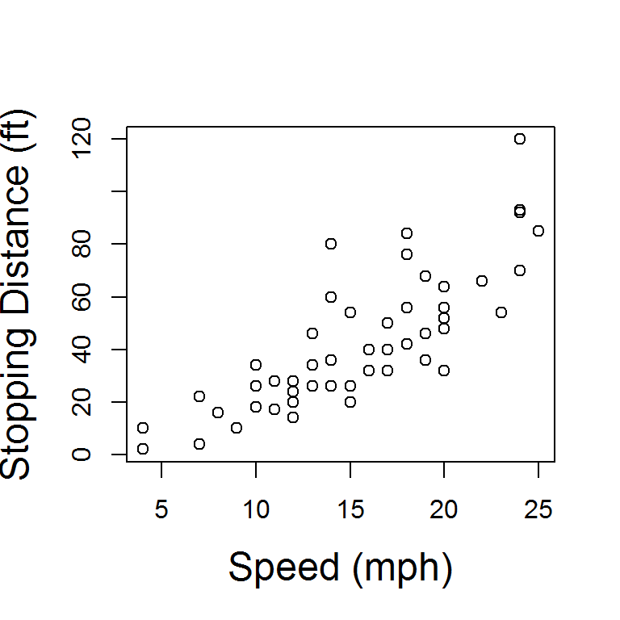

SHA-1 hash is a unique number for the file. If the file changes, its SHA-1 hash will change

## Computationally intensive analysis: `cache=TRUEE`

- knitr will first check if there’s previously cached results
- `cache.path` : set the cache directory
- Only be run when the chunk’s contents change or chunk option change

create an object Sample to a file called Sample.RData

````
   ```{r gen-data, cache=TRUE}
   # create data
   Sample<-rnorm(n=1000, mean=5, sd=2)
   # save sample
   save(Sample, file="Sample.RData")
   ```
````

latter code chunk for creating the histogram

````
   ```{r histgram, cache=TRUE, dependson='gen-data'}
   # load Sample
   load(file="Sample.RData")
   # create histogram
   hist(Sample)
   ```
````

## Running SAS code using chunk option `engine`

````
  ```{r, engine="sas", engine.path="C:/Program Files/SASHome/SASFoundation/9.4/sas.exe"}
  proc means data=sashelp.class;
  run;
  ```
````

SAS code and output

```sas
proc means data=sashelp.class;
run;
```

```
          Variable     N            Mean         Std Dev         Minimum         Maximum
          ------------------------------------------------------------------------------
          Age         19      13.3157895       1.4926722      11.0000000      16.0000000
          Height      19      62.3368421       5.1270752      51.3000000      72.0000000
          Weight      19     100.0263158      22.7739335      50.5000000     150.0000000
          ------------------------------------------------------------------------------
```

SAS HTML output (only works with HTML )

Variable

N

Mean

Std Dev

Minimum

Maximum

| Age |
| --- |
| Height |
| Weight |

| 19 |
| --- |
| 19 |
| 19 |

| 13.3157895 |
| --- |
| 62.3368421 |
| 100.0263158 |

| 1.4926722 |
| --- |
| 5.1270752 |
| 22.7739335 |

| 11.0000000 |
| --- |
| 51.3000000 |
| 50.5000000 |

| 16.0000000 |
| --- |
| 72.0000000 |
| 150.0000000 |

## Reproducibly Random : ‘set.seed’

```r
set.seed(123)
Draw1<-rnorm(1000, mean=0, sd=2)
summary(Draw1)
```

```
##     Min.  1st Qu.   Median     Mean  3rd Qu.     Max.
## -5.62000 -1.25700  0.01842  0.03226  1.32900  6.48200
```

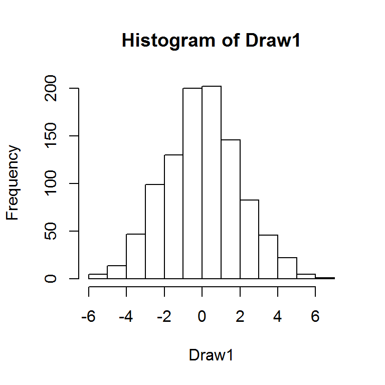

```r
hist(Draw1)
```

```r
set.seed(125)
Draw2<-rnorm(1000, mean=0, sd=2)
summary(Draw2)
```

```
##    Min. 1st Qu.  Median    Mean 3rd Qu.    Max.
## -7.2110 -1.4070 -0.1040 -0.1215  1.3160  5.6770
```

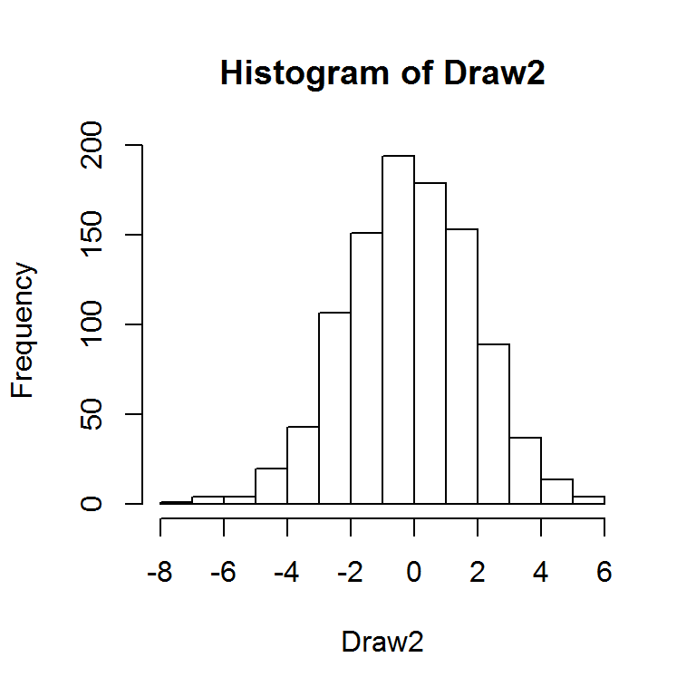

```r
hist(Draw2)
```